# Problem set 1

Alberto Marcos, Jorge Sopas, Sanskriti Jha, Victor Cornejo

2025-01-28

# PAPER 1

This section aims to replicate Figure 2 from the paper “Irrigation Dams, Water, and Infant Mortality: Evidence from South Africa”.

Load spatial datasets (district boundaries, elevation data, and dam locations). Compute river gradients (slope) using elevation data. Extract average slope per district to understand the variation in river gradients. Plot a map with dams and river gradients using ggplot2.

```r
{r}
# Required packages
install.packages(c("sf", "terra", "ggplot2", "dplyr", "exactextractr", "readxl"))
# The necessary libraries
library(sf)
library(terra)
library(ggplot2)
library(dplyr)
library(exactextractr)
library(readxl)
```

We will load:

- **District boundaries** (Shapefile): Defines municipal districts.
- **Topography data** (Raster): Elevation data for South Africa.
- **Dam locations** (Excel): Contains latitudes and longitudes of dams.

```r
{r}
# the district boundaries (vector data)
districts_sf <- st_read("/Users/sanskriti/Desktop/PLOT1/MDB_Local_Municipal_Boundary_2018.shp")

# elevation data (raster data)
topography_sf <- rast("/Users/sanskriti/Desktop/PLOT1/South African topography.tif")

# dam location data
dams_data <- read_excel("/Users/sanskriti/Desktop/Africa-dams_eng.xlsx", sheet = "Dams")
# Filter the dataset to only include dams in South Africa
sa_dams <- dams_data[dams_data$Country == "South Africa", ]
```

The **river gradient** determines how steep or flat a river flows.We calculate slope from the **elevation raster** using the `terrain()` function. `terrain(raster, v = "slope", unit = "degrees")`: Computes the **slope (gradient)** from elevation data. The unit `"degrees"` ensures we get values in **angle form**.

```r
{r}
library(terra)
print(topography_sf)
# Computing the slope in degrees
slope_raster <- terrain(topography_sf, v = "slope", unit = "degrees")

plot(slope_raster, main = "Slope Raster of South Africa")
```

[output not shown]

Extract the mean slope per district:

Each district has multiple slopes within its boundaries. We need to compute the **average slope per district** to summarize this data meaningfully. `exact_extract(raster, vector, "mean")`: Computes the **average slope** for each district by overlaying the raster onto the vector.

```r
{r}
# Extracting mean slope per district
districts_sf$avg_gradient <- exact_extract(slope_raster, districts_sf, "mean")
summary(districts_sf$avg_gradient)
```

Dam coordinates (latitude & longitude) are stored as **text** in the dataset. We must convert them into an **sf (spatial)** object for mapping. `st_as_sf()`: Converts a **data frame into a spatial object** with latitude & longitude.

```r
{r}
# Ensuring longitude and latitude columns are numeric
sa_dams$Longitude <- as.numeric(sa_dams$'Decimal degree longitude')
sa_dams$Latitude <- as.numeric(sa_dams$'Decimal degree latitude')
sum(is.na(sa_dams$`Decimal degree longitude`))
sum(is.na(sa_dams$`Decimal degree latitude`))

# Missing coordinates
sa_dams <- sa_dams[!is.na(sa_dams$`Decimal degree longitude`) &
                     !is.na(sa_dams$`Decimal degree latitude`), ]

# Converting dam data into an sf object
dams_sf <- st_as_sf(sa_dams, coords = c("Decimal degree longitude", "Decimal degree latitude"), crs = 4326)
dams_sf <- dams_sf %>%
  mutate(longitude = st_coordinates(.)[,1],
         latitude = st_coordinates(.)[,2])

head(dams_sf)
```

To ensure **all datasets align properly** on the map, they must share the **same coordinate system (CRS: EPSG 4326, WGS 84).** `st_transform()`: Converts vector layers to **EPSG 4326**. `project()`: Converts raster layers to **EPSG 4326.**

```r
{r}
install.packages("ggspatial")
library(ggspatial)
# Transforming vector layers to match WGS 84 (EPSG:4326)
districts_sf <- st_transform(districts_sf, crs = 4326)
dams_sf <- st_transform(dams_sf, crs = 4326)

topography_sf <- project(topography_sf, "EPSG:4326")
```

## Plot

Now, we visualize the **district boundaries, river gradients, and dam locations** using `ggplot2`.In the `ggplot()` code, we first plot the district boundaries using `geom_sf(data = districts_sf, aes(fill = avg_gradient), color = "white", size = 0.2)`, which fills each district with a shade based on its average river gradient (`avg_gradient`) while outlining them in white. Then, we overlay dam locations as black dots with `geom_sf(data = dams_sf, color = "black", size = 0.4, alpha = 0.7)`, . Next defining the map’s spatial extent using `coord_sf(xlim = c(16, 33), ylim = c(-35, -21), expand = FALSE, datum = NA)`, ensuring proper centering on South Africa . The grayscale gradient is set with `scale_fill_gradientn(colors = c("white", "gray", "black"), name = "Avg. River Gradient", breaks = c(2.5, 5, 7.5, 10, 12.5))`, where lighter shades represent flatter areas and darker ones indicate steeper slopes. Finally, `labs()` adds the title, subtitle, and data source, while `theme_minimal() + theme(legend.position = "bottom", text = element_text(size = 14), panel.grid = element_blank())` .

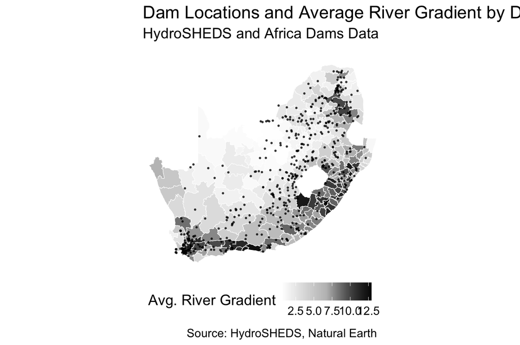

```r
{r}
library(ggplot2)
library(sf)

ggplot() +
  geom_sf(data = districts_sf, aes(fill = avg_gradient), color = "white", size = 0.2) +

  geom_sf(data = dams_sf, color = "black", size = 0.4, alpha = 0.7) +

  coord_sf(xlim = c(16, 33), ylim = c(-35, -21), expand = FALSE, datum = NA) +

  scale_fill_gradientn(colors = c("white", "gray", "black"),
                       name = "Avg. River Gradient",
                       breaks = c(2.5, 5, 7.5, 10, 12.5)) +

  labs(title = "Dam Locations and Average River Gradient by District",
       subtitle = "HydroSHEDS and Africa Dams Data",
       caption = "Source: HydroSHEDS, Natural Earth") +

  theme_minimal() +
  theme(
    legend.position = "bottom",
    text = element_text(size = 14),
    panel.grid = element_blank()
  )
```

# PAPER 2

This section aims to replicate Figure 4. “Ethiopian population density and ERSS sample villages.” from Fried, S. and Lagakos, D., 2021. Rural electrification, migration and structural transformation: Evidence from Ethiopia

The spatial datasets are loaded, including district boundaries, electricity grid, roads, and population density. The `st_read()` function is used for vector data such as district boundaries, the electricity grid, and roads, while the `raster()` function is used to read the population density raster.

```r
{r}
install.packages(c("sf", "ggplot2", "tmap", "sp", "raster"))
library(sf)
library(ggplot2)
library(tmap)
library(sp)
library(raster)


districts <- st_read("C:/Users/amarc/Downloads/plot 2 data/plot 2 data/geoBoundaries-ETH-ADM2-all/geoBoundaries-ETH-ADM2_simplified.shx")
districts
st_drivers()
electricity_grid <- st_read("C:/Users/amarc/Downloads/plot 2 data/plot 2 data/ethiopia-electricity-transmission-network/Ethiopia Electricity Transmission Network.shx")
population_density <- raster("C:/Users/amarc/Downloads/plot 2 data/plot 2 data/eth_pd_2012_1km_ASCII_XYZ.csv")
roads <- st_read("C:/Users/amarc/Downloads/plot 2 data/plot 2 data/ethiopia-latest-free.shp/gis_osm_roads_free_1.shx")
```

The population density raster is cropped to match the extent of the district boundaries using `crop()`. Then, `mask()` is applied to ensure that only areas within the district boundaries retain values, while areas outside the boundaries are masked out. To ensure all spatial datasets align correctly, they are transformed to a common coordinate reference system (CRS). The CRS of the district boundaries is retrieved using `st_crs(districts)`, and the electricity grid and roads are then transformed to match this CRS using `st_transform()`.

```r
{r}
population_density <- mask(crop(population_density, districts), districts)
crs_target <- st_crs(districts)
electricity_grid <- st_transform(electricity_grid, crs_target)
roads <- st_transform(roads, crs_target)
```

Since raster data consists of continuous grid cells, it is converted into discrete points for spatial analysis. The `rasterToPoints()` function extracts values from the raster and stores them as individual points. The extracted points are then converted into an `sf` object for compatibility with spatial operations.

```r
{r}
class(roads)
population_df <- as.data.frame(rasterToPoints(population_density))
primary_roads <- roads[roads$fclass == "secondary", ]


# Convert raster to points
population_points <- rasterToPoints(population_density, spatial = TRUE)
# Convert to sf object
population_sf <- st_as_sf(population_points)
```

To associate each population point with its corresponding district, a spatial join is performed using `st_join()`. This assigns district information to each population density point. The population density values are aggregated at the district level. The aggregated population density values are merged with the district boundaries dataset using `left_join()`, ensuring that each district now contains its corresponding population density value.

```r
{r}
#  spatial join
population_joined <- st_join(population_sf, districts)
population_density_aggregated <- population_joined %>%
  group_by(shapeID) %>%
  summarize(mean_density = mean(eth_pd_2012_1km_ASCII_XYZ, na.rm = TRUE))
population_density_aggregated_df <- as.data.frame(population_density_aggregated)

districts_filled <- districts %>%
  left_join(population_density_aggregated_df, by = "shapeID")

# Convert population_df back to a raster object
population_raster <- rasterFromXYZ(population_df[, c("x", "y", "eth_pd_2012_1km_ASCII_XYZ")])

crs(population_raster) <- st_crs(districts)$proj4string
```

## Plot

Now, we visualize the **population density, electricity grid, and road** using `tmap`. The map is created using `tmap`. The districts are shaded based on population density using `tm_polygons()`, roads are overlaid using `tm_lines(col = "black")`, and the electricity grid is displayed in red using `tm_lines(col = "red")`. A custom blue color palette is applied to the population density shading, and the map layout is adjusted to remove the frame and hide the legend. `tmap` was a closer representation of the figure when compared to `ggplot2`

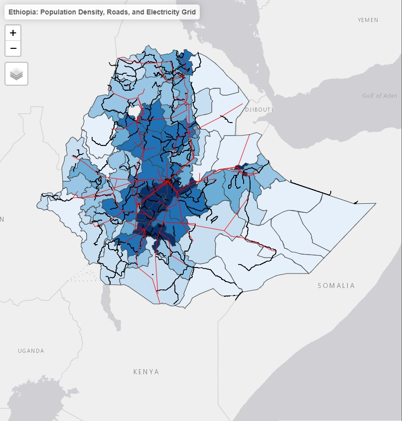

```r
{r}
library(tmap)
tmap_mode("view")
tm_shape(districts_filled) +
  tm_polygons(
    col = "mean_density",
    palette = c("#e6f0fa", "#c8dff1", "#98c6e4", "#6daed6", "#2171b5", "#08306b"),  # Custom blue palette
    style = "quantile",
    n = 6  # Number of bins
  ) +
  tm_shape(primary_roads) +
  tm_lines(col = "black", lwd = 1.25) +  # Thicker black lines for primary roads
  tm_shape(electricity_grid) +
  tm_lines(col = "red", lwd = 1) +  # Electricity grid in red
  tm_layout(
    main.title = "Ethiopia: Population Density, Roads, and Electricity Grid",
    frame = FALSE,  # Remove the map frame
    legend.show = FALSE
  )
```

# PAPER 3

This section aims to replicate Figure. 2: Population in Brazil’s meso-regions (or districts) in different periods from Pellegrina, H.S. and Sotelo, S., 2021. Migration, Specialization, and Trade: Evidence from Brazil’s March to the West.

The dataset of Brazil’s meso-regions is loaded using `st_read()`, ensuring the correct administrative divisions are available for mapping. The dataset is then grouped by meso-region using `group_by(nomemeso)`, aggregating geometries with `st_union()`. Additionally, specific region names are corrected with `mutate()` to maintain consistency in naming conventions.

```r
{r}
library(sf)
library(dplyr)
library(readxl)

gdf <- st_read("C:/Users/amarc/Downloads/microrregioes_e_mesorregioes_geograficas_1990/RG2017_micromeso89.shp")

gdf_grouped <- gdf %>%
  group_by(nomemeso) %>%
  summarise(
    UF = first(UF),  # Keeps the first UF encountered for each mesoregion
    geometry = st_union(geometry)  # Merges geometries
  )

# Renaming the specific values in the "nomemeso" column of gdf_grouped
gdf_grouped <- gdf_grouped %>%
  mutate(nomemeso = case_when(
    nomemeso == "Sul - Sudoeste de Minas" ~ "Sul/Sudoeste de Minas",
    nomemeso == "Triângulo Mineiro - Alto Paranaíba" ~ "Triângulo Mineiro/Alto Paranaíba",
    TRUE ~ nomemeso
  ))
```

It is then merged with the spatial data using `left_join()` on the `nomemeso` column to associate population data with meso-regions. The North and Central-West regions are identified using their `UF` codes. These regions will later be highlighted in the visualization.

```r
{r}
population_data <- read_excel("C:/Users/amarc/Downloads/ipeadata[28-01-2025-07-03].xls")

merged_data <- gdf_grouped %>%
  left_join(population_data, by = c("nomemeso" = "Meso-região"))
head(merged_data)

# Define the UF codes for North and Central-West regions
highlighted_uf_codes <- c(11, 12, 13, 14, 15, 16, 17, 50, 51, 52, 53)
```

Population data is normalized by dividing each year’s population by the total population in that year, creating a relative measure (`pop_share`). The population shares are classified into quantile-based bins to create meaningful population categories for mapping. This is done using `cut()` and `quantile()`. The North and Central-West regions are extracted and merged into a single boundary to highlight them in the final visualization.

```r
{r}
years <- c("1950", "1980", "2010")

# Normalize population by total population per year
for (year in years) {
  merged_data[[paste0("pop_share_", year)]] <- merged_data[[year]] / sum(merged_data[[year]], na.rm = TRUE)
}

# Function to classify population shares into 5 equal-size bins using quantiles
classify_population <- function(year) {
  pop_column <- paste0("pop_share_", year)

  # quantile-based breaks ensuring 5 groups
  breaks <- quantile(merged_data[[pop_column]], probs = seq(0, 1, length.out = 6), na.rm = TRUE)


  labels <- paste0(round(breaks[-6], 3), " - ", round(breaks[-1], 3))


  merged_data[[paste0("pop_class_", year)]] <<- cut(merged_data[[pop_column]], breaks = breaks, include.lowest = TRUE, labels = labels)
}
```

## Plot

The `ggplot()` function is used to generate separate maps for 1950, 1980, and 2010. The meso-regions are colored according to their population share categories, while the North and Central-West boundaries are outlined in red.

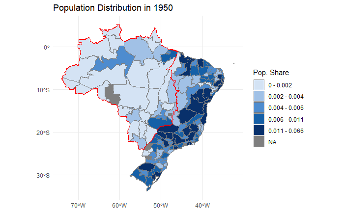

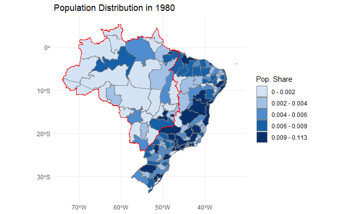

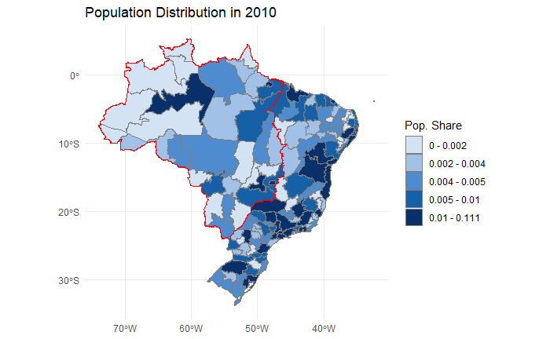

```r
{r}

library(ggplot2)
color_palette <- c("#D4E3F4", "#A1C1E6", "#4E8CCF", "#1660A7", "#08306B")

# Create a separate dataset containing only the North and Central-West regions
highlighted_data <- merged_data %>% filter(UF %in% highlighted_uf_codes)

highlighted_boundary <- highlighted_data %>%
  summarise(geometry = st_union(geometry)) %>%  # Merge into a single polygon
  st_cast("MULTILINESTRING")  # Ensure it’s a single continuous border

# Function to create a population share map with only the **outer** border in red
create_map <- function(year) {
  ggplot() +

    # Mesoregion borders (grey)
    geom_sf(data = merged_data, aes(fill = get(paste0("pop_class_", year))), color = "grey50", size = 0.2) +

    # Highlighting region's **outer boundary only** (red)
    geom_sf(data = highlighted_boundary, color = "red", fill = NA, size = 1) +

    # Color scale for population share
    scale_fill_manual(values = color_palette, name = "Pop. Share", drop = FALSE) +

    theme_minimal() +
    ggtitle(paste("Population Distribution in", year))
}

# Generating maps for 1950, 1980, and 2010
map_1950 <- create_map("1950")
map_1980 <- create_map("1980")
map_2010 <- create_map("2010")

print(map_1950)
print(map_1980)
print(map_2010)
```

# PAPER 4

This section aims to replicate Figure 3: Road maps of Vietnam, 2000 and 2010 from Balboni, C.A., 2019. In harm’s way? infrastructure investments and the persistence of coastal cities

The code starts by loading necessary libraries, including `sf`, `ggplot2`, `dplyr`, and `rnaturalearth`, which are used for handling spatial data and visualizing maps. The `ne_countries()` function retrieves the country boundary of Vietnam as an `sf` object for spatial operations. The `st_intersection()` function is used to clip the Asia-wide road network to Vietnam’s borders, ensuring that only Vietnam’s roads are retained.

```r
{r}
install.packages("remotes")
remotes::install_github("ropensci/rnaturalearthhires")
library(rnaturalearthhires)
library(sf)
library(ggplot2)
library(dplyr)
library(rnaturalearth)
library(rnaturalearthdata)

vietnam <- ne_countries(scale = "large",
                        country = "Vietnam", returnclass = "sf")


asia_roads <- read_sf("/Users/jorgesopas/Downloads/groads-v1-asia-shp/groads-v1-asia.shp")
vietnam_roads <- st_intersection(asia_roads, vietnam)

another_vietnam_roads <- read_sf("/Users/jorgesopas/Downloads/vnm_rdsl_2015_osm", "vnm_rdsl_2015_osm")
```

## Plot

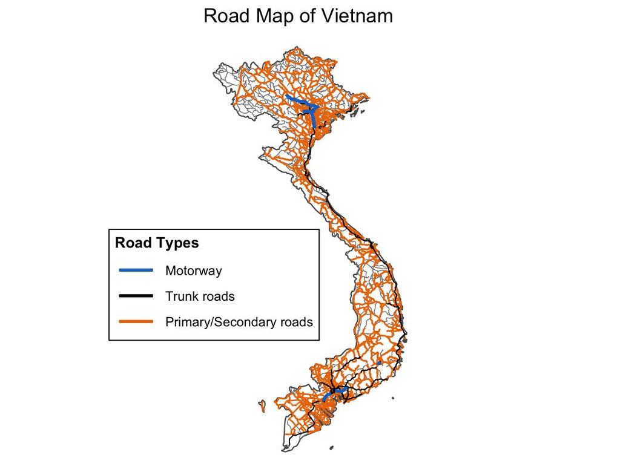

[figure not shown]

```r
{r}

ggplot() +
  geom_sf(data = vietnam, linewidth = 0.4,
          fill = "white") +
  # plot all roads and categorize them as other roads
  geom_sf(data = vietnam_roads, linewidth = 0.25, color = "grey50") +  # Cor válida para "Other roads"
  geom_sf(data = another_vietnam_roads %>%
            filter(type %in% c("primary", "secondary")),
          aes(color = "Primary/Secondary roads"), linewidth = 0.5, show.legend = "line") +
  # plot specific roads and categorize their types
  geom_sf(data = another_vietnam_roads %>%
            filter(type == "trunk"),
          aes(color = "Trunk roads"), linewidth = 0.37, show.legend = "line") +
  # plot specific roads and categorize their type as motorway
  geom_sf(data = another_vietnam_roads %>%
            filter(type == "motorway"),
          aes(color = "Motorway"), linewidth = 1, show.legend = "line") +
  # add options to modify the default theme
  labs(title = "Road Map of Vietnam") +
  theme_void() +
  scale_color_manual(
    name = "Road Types",
    values = c(
      "Primary/Secondary roads" = "darkorange2",
      "Trunk roads" = "black",
      "Motorway" = "dodgerblue3"
    ),
    breaks = c("Motorway", "Trunk roads", "Primary/Secondary roads")
  ) +
  theme(
    legend.key.width = unit(1, "cm"),
    legend.position = c(0.05, 0.42),  # Corrige a posição da legenda
    legend.background = element_rect(color = "black"),
    legend.title = element_text(size = 10, face = "bold"),
    legend.margin = margin(4, 4, 4, 4)
  )
```

# PAPER 5

This section aims to replicate Figure 1: Map of straight-line instrument and radial highways from Morten, M. & Oliveira, J., 2018. The Effects of Roads on Trade and Migration: Evidence from a Planned Capital City.

The spatial datasets required for mapping Brazil’s infrastructure are loaded. The `ne_states()` function from the `rnaturalearth` package is used to retrieve Brazil’s state boundaries in `sf` format. The `st_read()` function is then used to read the shapefiles for federal and state highways, ensuring they are stored as spatial objects for further analysis. A dataset is manually created containing the state names and their respective capitals. This mapping allows for the identification and visualization of state capitals.

```r
{r}
install.packages("devtools")
devtools::install_github("ropensci/rnaturalearthhires")
library(rnaturalearthhires)
library(rnaturalearth)
library(rnaturalearthdata)
library(rnaturalearthhires)
brazil <- ne_states(country = "Brazil", returnclass = "sf")


library(sf)
# Brazil's federal highways
federal_highways <- st_read("C:/Users/amarc/Downloads/plot 5/plot 5/br-federal-highways-2020/SNV_202001A.shx")

# Brazil's state highways
state_highways <- st_read("C:/Users/amarc/Downloads/plot 5/plot 5/br-state-highways-2018/RODOVIAS_ESTADUAIS_SRE2.shx")

state_capitals <- data.frame(
  state = c(
    "Acre", "Alagoas", "Amapá", "Amazonas", "Bahia", "Ceará",
    "Distrito Federal", "Espírito Santo", "Goiás", "Maranhão", "Mato Grosso",
    "Mato Grosso do Sul", "Minas Gerais", "Pará", "Paraíba", "Paraná",
    "Pernambuco", "Piauí", "Rio de Janeiro", "Rio Grande do Norte",
    "Rio Grande do Sul", "Rondônia", "Roraima", "Santa Catarina",
    "São Paulo", "Sergipe", "Tocantins"
  ),
  capital = c(
    "Rio Branco", "Maceió", "Macapá", "Manaus", "Salvador", "Fortaleza",
    "Brasília", "Vitória", "Goiânia", "São Luís", "Cuiabá",
    "Campo Grande", "Belo Horizonte", "Belém", "João Pessoa", "Curitiba",
    "Recife", "Teresina", "Rio de Janeiro", "Natal",
    "Porto Alegre", "Porto Velho", "Boa Vista", "Florianópolis",
    "São Paulo", "Aracaju", "Palmas"
  ),
  stringsAsFactors = FALSE
)
```

The capital names are joined with the Brazil state boundaries using `left_join()`. The `st_make_valid()` function ensures geometries are correctly processed. Centroids of states are computed using `st_centroid()`, which provides approximate locations of capitals.

```r
{r}
library(dplyr)
library(sf)

# Join the capitals to the state geometries
brazil_with_capitals <- brazil %>%
  left_join(state_capitals, by = c("name" = "state"))
brazil_with_capitals <- brazil_with_capitals %>%
  mutate(geometry = st_make_valid(geometry))
capitals_sf <- brazil_with_capitals %>%
  filter(!is.na(capital)) %>%  # Keep only rows with valid capitals
  mutate(capital_coords = st_centroid(geometry)) %>%  # Calculate centroids
  st_as_sf()
capitals_sf <- capitals_sf %>%
  select(capital, capital_coords) %>%
  st_set_geometry("capital_coords")
plot(st_geometry(capitals_sf), main = "Brazilian State Capitals")
```

[output not shown]

A graph is constructed from the state capitals’ coordinates using `igraph`. A minimum spanning tree (MST) is computed, which represents the shortest possible network connecting all capitals while minimizing total distance.

```r
{r}
library(igraph)
capitals_coords <- st_coordinates(capitals_sf)

# Calculate distance matrix
distance_matrix <- as.matrix(dist(capitals_coords))

g <- graph_from_adjacency_matrix(distance_matrix, weighted = TRUE, mode = "undirected")
mst <- mst(g)

# Extract MST edges
mst_edges <- as_data_frame(mst, what = "edges")
mst_edges$from <- as.integer(mst_edges$from)
mst_edges$to <- as.integer(mst_edges$to)

# Create spatial lines for the MST
lines_list <- lapply(1:nrow(mst_edges), function(i) {
  st_linestring(rbind(
    capitals_coords[mst_edges$from[i], ],
    capitals_coords[mst_edges$to[i], ]
  ))
})

# Convert MST to sf object
mst_sf <- st_sfc(lines_list, crs = st_crs(capitals_sf))
mst_sf <- st_sf(geometry = mst_sf)
```

The radial highways are identified by filtering highways within a 50 km buffer around Brasília, assuming these highways originate from the capital. Highways that do not pass through Brasília are classified as non-radial.

```r
{r}
library(sf)
# Define Brasília's location (latitude and longitude)
brasilia_coords <- st_point(c(-47.9292, -15.7801))
brasilia_buffer <- st_sfc(brasilia_coords, crs = st_crs(federal_highways)) %>%
  st_buffer(dist = 50000)  # 50 km buffer around Brasília

radial_highways <- federal_highways[st_intersects(federal_highways, brasilia_buffer, sparse = FALSE), ]
non_radial_highways <- federal_highways %>%
  filter(!(ds_local_i == "Brasília" | ds_local_f == "Brasília"))
```

All spatial datasets are transformed to the EPSG 4326 coordinate reference system to ensure compatibility in plotting.

```r
{r}
st_crs(radial_highways)
st_crs(non_radial_highways)
st_crs(mst_sf)
st_crs(capitals_sf)
brazil <- st_set_crs(brazil, 4674)
brazil <- st_transform(brazil, 4326)
radial_highways <- st_transform(radial_highways, 4326)
non_radial_highways <- st_transform(non_radial_highways, 4326)
mst_sf <- st_transform(mst_sf, 4326)
capitals_sf <- st_transform(capitals_sf, 4326)
```

## Plot

The `ggplot()` function initializes the map, starting with `geom_sf(data = brazil, fill = "white", color = "black", size = 0.4)`, which plots Brazil’s boundaries with a black outline. The `geom_sf(data = radial_highways, color = "grey", size = 0.4, linetype = "solid")` layer overlays radial highways as solid grey lines, while `geom_sf(data = non_radial_highways, color = "grey", size = 0.4, linetype = "dashed")` adds non-radial highways as dashed grey lines. The minimum spanning tree (MST) is displayed using `geom_sf(data = mst_sf, color = "black", size = 0.6, linetype = "dotted")`, which connects state capitals optimally. Capitals are represented as black points with `geom_sf(data = capitals_sf, color = "black", size = 2)`. City labels are added with `geom_text()`, extracting coordinates from `capitals_sf` and aligning labels slightly offset for readability.

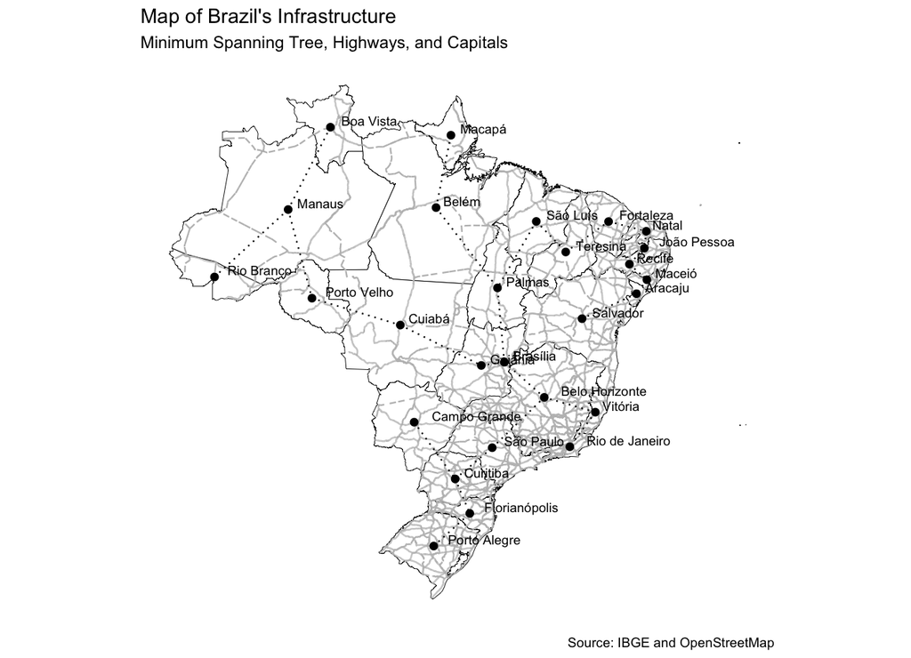

```r
{r}

library(ggplot2)
ggplot() +
  geom_sf(data = brazil, fill = "white", color = "black", size = 0.4) +
  geom_sf(data = radial_highways, color = "grey", size = 0.4, linetype = "solid") +

  geom_sf(data = non_radial_highways, color = "grey", size = 0.4, linetype = "dashed") +

  geom_sf(data = mst_sf, color = "black", size = 0.6, linetype = "dotted") +

  geom_sf(data = capitals_sf, color = "black", size = 2) +

  geom_text(data = capitals_sf %>% st_drop_geometry(),
            aes(x = st_coordinates(capitals_sf)[, 1],
                y = st_coordinates(capitals_sf)[, 2],
                label = capital),
            size = 3, hjust = -0.2, vjust = -0.2) +

  labs(
    title = "Map of Brazil's Infrastructure",
    subtitle = "Minimum Spanning Tree, Highways, and Capitals",
    caption = "Source: IBGE and OpenStreetMap"
  ) +

  theme_minimal() +
  theme(
    panel.grid.major = element_blank(),
    panel.grid.minor = element_blank(),
    axis.text = element_blank(),
    axis.ticks = element_blank(),
    axis.title = element_blank()
  )
```